# postgressdataconnection

## Customer Churn Analytics Project

Objective: Analyze customer churn to find key insights and inform retention strategies.

```python
import pandas as pd
```

```python
import pandas as pd
import psycopg2

conn = psycopg2.connect(
    host='localhost',
    database='ecommerce_churn',
    user='postgres',
    password='viplav1999'
)

query = "SELECT ROUND(100.0 * SUM(Churn) / COUNT(*), 2) AS churn_rate_percent FROM customer_churn;"
df_overall_churn = pd.read_sql(query, conn)
conn.close()
```

```python
print(df_overall_churn.head())
```

```
   churn_rate_percent
0               26.13
```

## 1. 🟢 Overall Customer Churn Rate

We first established the overall customer churn rate to set a baseline for our segmentation analysis.

- **Overall Churn:** **26.1%**
- **Actionable Insight:** The high churn rate of over one quarter of the customer base demands detailed investigation into contributing segments.

```python
print(df_overall_churn.head())
```

```
   churn_rate_percent
0               26.13
```

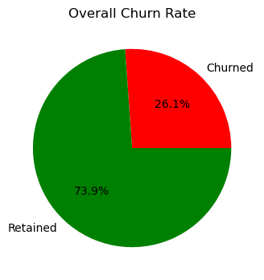

```python
churn_rate_percent = df_overall_churn['churn_rate_percent'][0]
plt.figure(figsize=(4, 4))
plt.pie([churn_rate_percent, 100-churn_rate_percent], labels=['Churned', 'Retained'], autopct='%.1f%%', colors=['red', 'green'])
plt.title('Overall Churn Rate')
plt.show()
```

## 2. 📱 Churn Rate by Device

```python
import psycopg2
import pandas as pd
import matplotlib.pyplot as plt
import seaborn as sns

conn = psycopg2.connect(
    host='localhost',
    database='ecommerce_churn',
    user='postgres',
    password='viplav1999'  # your password, if empty use ''
)
```

```python
query_high_churn = """
SELECT
  deviceused,
  ROUND(100.0 * AVG(churn), 2) AS churn_rate_percent
FROM customer_churn
GROUP BY deviceused
ORDER BY churn_rate_percent DESC;
"""
df_high_churn = pd.read_sql(query_high_churn, conn)
print(df_high_churn.columns)
print(df_high_churn.head())
```

```
Index(['deviceused', 'churn_rate_percent'], dtype='object')
  deviceused  churn_rate_percent
0     Tablet               26.94
1     Mobile               26.03
2    Desktop               25.40
```

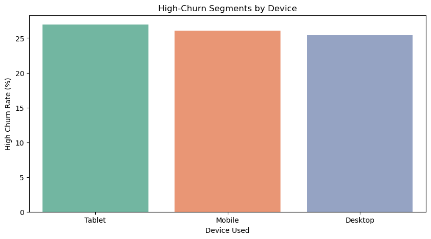

```python
import seaborn as sns

plt.figure(figsize=(10, 5))
sns.barplot(
    x='deviceused',
    y='churn_rate_percent',
    data=df_high_churn,
    palette='Set2'
)
plt.xlabel('Device Used')
plt.ylabel('High Churn Rate (%)')
plt.title('High-Churn Segments by Device')
plt.show()
```

## 3. Churn Rate by Membership Status.

We segmented the churn rate by membership status (Premium vs. Non-Premium) to understand if the paid tier effectively drives retention.

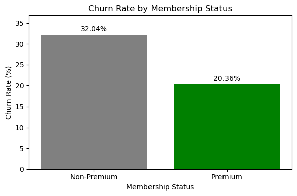

```python
import pandas as pd
import matplotlib.pyplot as plt

# Data from the SQL query (Non-Premium is 0, Premium is 1)
sql_data = {
    'haspremiummembership': [0, 1],
    'churn_rate_percent': [32.04, 20.36],
    'user_count': [4941, 5059]
}
df_premium_churn = pd.DataFrame(sql_data)

plt.figure(figsize=(6, 4))

# Plot the bars
# Color order is: 'grey' for Non-Premium (higher churn), 'green' for Premium (lower churn)
bars = plt.bar(
    df_premium_churn['haspremiummembership'],
    df_premium_churn['churn_rate_percent'],
    color=['grey', 'green']
)

# Adding Data Labels
for bar in bars:
    height = bar.get_height()
    plt.text(
        bar.get_x() + bar.get_width() / 2.,
        1.02 * height,
        f'{height:.2f}%', # Format to 2 decimal places and add '%'
        ha='center',
        va='bottom',
        fontsize=10
    )

# Customizing X-axis ticks with descriptive labels
plt.xticks(
    df_premium_churn['haspremiummembership'],
    ['Non-Premium', 'Premium']
)

plt.xlabel('Membership Status')
plt.ylabel('Churn Rate (%)')
plt.title('Churn Rate by Membership Status')
# Adjust y-limit to ensure labels are visible above the bars
plt.ylim(0, max(df_premium_churn['churn_rate_percent']) * 1.15)

plt.tight_layout()
plt.show()
```

## 4. 💸 Analysis of Revenue Lost Due to Churn

To quantify the financial cost of customer attrition, we calculated the total revenue lost from customers who churned.

- **Total Revenue Lost:** ₹7,316,316.5899 **
- **Context:** This substantial figure provides the financial justification for all retention initiatives identified in the subsequent analysis.

```python
total_revenue_lost = df_rev_lost['total_revenue_lost'][0]
print("Total Revenue Lost due to Churn: ₹{:,}".format(total_revenue_lost))
```

```
Total Revenue Lost due to Churn: ₹7,316,316.589999993
```

## 5. ⏱️ Churn Rate by Customer Tenure

Customer retention often correlates with the time a customer has been with the service. Analyzed churn across three tenure buckets: New (0-6 mo.), Mid-Term (6-24 mo.), and Long-Term (24+ mo.).

- **Observation:** **New Customers (0-6 mo.)** have the highest churn rate (**35.20%**), while Mid-Term and Long-Term customers show similar, lower rates (approx. **25%**).
- **Actionable Insight:** The initial 6-month period is the most critical for retention. Onboarding and initial engagement strategies must be prioritized to mitigate this early churn risk.

```python
query_tenure_bucket = """
SELECT
  CASE
    WHEN tenuremonths < 6 THEN 'New (0-6 mo.)'
    WHEN tenuremonths < 24 THEN 'Mid-Term (6-24 mo.)'
    ELSE 'Long-Term (24+ mo.)'
  END AS tenure_group,
  ROUND(100.0 * AVG(churn), 2) AS churn_rate_percent
FROM customer_churn
GROUP BY tenure_group
ORDER BY churn_rate_percent DESC;
"""
```

```python
import psycopg2

conn = psycopg2.connect(
    host='localhost',
    database='ecommerce_churn',
    user='postgres',
    password='viplav1999'  # Put your password here; if no password, leave as empty quotes
)
```

```python
df_tenure_bucket = pd.read_sql(query_tenure_bucket, conn)
print(df_tenure_bucket.columns)
print(df_tenure_bucket)
```

```
Index(['tenure_group', 'churn_rate_percent'], dtype='object')
          tenure_group  churn_rate_percent
0        New (0-6 mo.)               35.20
1  Long-Term (24+ mo.)               25.16
2  Mid-Term (6-24 mo.)               24.49
```

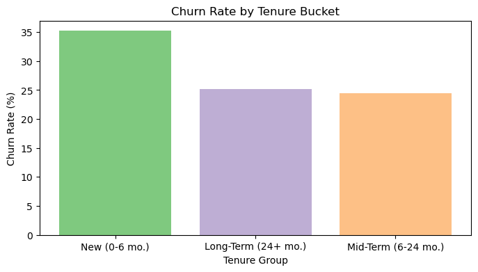

```python
colors = ["#7FC97F", "#BEAED4", "#FDC086"]  # 3 distinct colors for buckets
plt.figure(figsize=(8,4))
plt.bar(df_tenure_bucket['tenure_group'], df_tenure_bucket['churn_rate_percent'], color=colors)
plt.xlabel('Tenure Group')
plt.ylabel('Churn Rate (%)')
plt.title('Churn Rate by Tenure Bucket')
plt.show()
```

## 6. 📈 Feature Correlation with Churn

To identify potential drivers, we examined the correlation between key quantitative features (Tenure Months, Total Spend, Support Tickets) and the likelihood of a customer churning.

- **Key Finding:** The number of **Support Tickets** shows the strongest positive correlation with churn, indicating that high engagement with customer service is a significant churn predictor.
- **Context:** Conversely, **Tenure Months** and **Total Spend** show a weak negative correlation, suggesting that as these values increase, churn slightly decreases. This reinforces the need to fix service issues quickly.

```python
query_corr = """
SELECT
  ROUND(CORR(churn, tenuremonths)::numeric, 2) AS tenure_churn_corr,
  ROUND(CORR(churn, totalspend)::numeric, 2) AS spend_churn_corr,
  ROUND(CORR(churn, supporttickets)::numeric, 2) AS ticket_churn_corr
FROM customer_churn;
"""
df_corr = pd.read_sql(query_corr, conn)
print(df_corr.columns)
print(df_corr.head())
```

```
Index(['tenure_churn_corr', 'spend_churn_corr', 'ticket_churn_corr'], dtype='object')
   tenure_churn_corr  spend_churn_corr  ticket_churn_corr
0              -0.04             -0.04               0.23
```

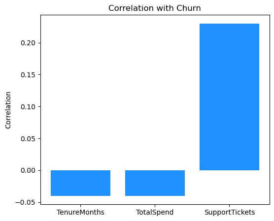

```python
features = ['TenureMonths', 'TotalSpend', 'SupportTickets']
corrs = [
    df_corr['tenure_churn_corr'][0],
    df_corr['spend_churn_corr'][0],
    df_corr['ticket_churn_corr'][0]
]
plt.figure(figsize=(6,5))
plt.bar(features, corrs, color='dodgerblue')
plt.ylabel('Correlation')
plt.title('Correlation with Churn')
plt.show()
```